# section_4.6(Final)

```python
# 4.6
# Importing necessary packages
import numpy as np
import matplotlib.pyplot as plt
from astropy.io import fits
import astroalign as aa
# This imports the astroalign library, which provides tools for aligning astronomical images.
# It can be used to match the coordinates of different images based on their celestial objects,
# facilitating image comparison and analysis.
from scipy import stats, optimize
from IPython.display import display, Image
# This imports display and Image from the IPython display module, which allows for rendering
# images and other rich content in Jupyter notebooks.
# The display function is used to display Python objects (like images),
# while Image is used to load and display image files.
```

This section applies the experiences gained from previous sections of the lab to astrophotography, focusing on calibrating and reducing data. The target we selected to take picture is Messier 57 (M57), the Ring Nebula. Our goal is to capture a high-quality RGB image of M57 using the calibration techniques developed earlier.

```python
def read_and_align_pretty_images(red_template, blue_template, visible_template, start_index, end_index):
    """
    Read the pretty images (red, blue, visible) of the specified astronomical object,
    align the blue and visible images to the red image for each frame, and then
    calculate the median images for each band.

    :param red_template: Template path for the red images with placeholders for the frame number.
    :type red_template: str
    :param blue_template: Template path for the blue images with placeholders for the frame number.
    :type blue_template: str
    :param visible_template: Template path for the visible images with placeholders for the frame number.
    :type visible_template: str
    :param start_index: The starting index for the image frames.
    :type start_index: int
    :param end_index: The ending index for the image frames.
    :type end_index: int
    :return: A tuple containing the aligned images for each band and the median images.
    :rtype: tuple (list of tuples, np.ndarray, np.ndarray, np.ndarray, np.ndarray, np.ndarray, np.ndarray)
    """
    # Load and align images for each color band
    red_images, blue_images, visible_images = [], [], []
    for i in range(start_index, end_index + 1):
        # Construct file paths
        red_file = red_template.format(i)
        blue_file = blue_template.format(i)
        visible_file = visible_template.format(i)
         # Read FITS files
    with fits.open(red_file) as red_hdul, \
         fits.open(blue_file) as blue_hdul, \
         fits.open(visible_file) as visible_hdul:
        red_data = red_hdul[0].data
        blue_data = blue_hdul[0].data
        visible_data = visible_hdul[0].data
        # Use red frame as reference for alignment
        aligned_blue, _ = aa.register(blue_data, red_data)
        aligned_visible, _ = aa.register(visible_data, red_data)
        # Store aligned images
        red_images.append(red_data)
        blue_images.append(aligned_blue)
        visible_images.append(aligned_visible)
    # Convert lists to numpy arrays for median calculation
    red_images = np.array(red_images)
    blue_images = np.array(blue_images)
    visible_images = np.array(visible_images)
    # Calculate median images for each band
    median_red = np.median(red_images, axis=0)
    median_blue = np.median(blue_images, axis=0)
    median_visible = np.median(visible_images, axis=0)
    # Return the aligned images and median images
    return (red_images, blue_images, visible_images), median_red, median_blue, median_visible

# Template for the file names
red_file_template = r"..\FITS_Files\ring_nebula_for_10_sec_red.{:08d}.FIT"
blue_file_template = r"..\FITS_Files\ring_nebula_for_10_sec_blue.{:08d}.FIT"
visible_file_template = r"..\FITS_Files\ring_nebula_for_10_sec_visible.{:08d}.FIT"

# Define the starting and ending indices
pretty_start_index = 0
pretty_end_index = 2

# Call the function
pretty_images, median_red, median_blue, median_visible = read_and_align_pretty_images(
    red_file_template, blue_file_template, visible_file_template, pretty_start_index, pretty_end_index
)
```

```python
def read_dark_frames(file_template, start_index, end_index):
    """
    Read dark frames from FITS files and calculate their median dark frame.

    :param file_template: Template path for the dark files with placeholders for the frame number.
    :type file_template: str
    :param start_index: The starting index for the dark frames.
    :type start_index: int
    :param end_index: The ending index for the dark frames.
    :type end_index: int
    :return: A tuple containing a list of headers and data of the loaded dark frames,
             and the median dark frame.
    :rtype: tuple (list of tuples, np.ndarray)
    """
    # List to store the FITS data and headers
    dark_frame_info = []
    # Loop through each dark frame and read the data
    for i in range(start_index, end_index + 1):
        # Construct the file name based on the frame number
        file_path = file_template.format(i)
        # Open the FITS file and read the header and data
        with fits.open(file_path) as hdul:
            header = hdul[0].header
            data = hdul[0].data
            # Store the header and data
            dark_frame_info.append((header, data))
    # Calculate the median dark frame
    dark_frames_data = np.array([frame[1] for frame in dark_frame_info])
    median_dark_frame = np.median(dark_frames_data, axis=0)

    return dark_frame_info, median_dark_frame

# Template for the dark frame file names
dark_frame_file_template = r"..\FITS_Files\ring_nebula_dark_frame_10_sec.{:08d}.DARK.FIT"

# Define the starting and ending indices
dark_start_index = 4
dark_end_index = 6

# Call the function
dark_frames_info, median_dark_frame = read_dark_frames(dark_frame_file_template, dark_start_index, dark_end_index)
```

The `read_dark_frames` function is designed to read dark frames from FITS files and compute their median dark frame. It takes a file path template that includes placeholders for frame numbers, as well as starting and ending indices for the frames to be processed. Within the function, a loop iterates through the specified range of indices, constructing the file paths for each dark frame. For each file, it opens the FITS file, extracts both the header and data, and appends this information to a list. Once all frames have been read, the function calculates the median dark frame by converting the collected data into a NumPy array and applying the `np.median()` function along the first axis. Finally, the function returns a tuple containing the list of dark frame headers and data, along with the computed median dark frame for further analysis or calibration purposes.

```python
def read_and_process_flat_fields(file_template, start_index, end_index, median_dark_frame):
    """
    Read flat field frames from FITS files, calculate the median flat field, subtract the median dark frame,
    and normalize by dividing by the mode.

    :param file_template: Template path for the flat field files with placeholders for the frame number.
    :type file_template: str
    :param start_index: The starting index for the flat field frames.
    :type start_index: int
    :param end_index: The ending index for the flat field frames.
    :type end_index: int
    :param median_dark_frame: The median dark frame to be subtracted from the flat field frames.
    :type median_dark_frame: np.ndarray
    :return: A tuple containing a list of headers and data of the loaded flat field frames,
             and the normalized median flat field.
    :rtype: tuple (list of tuples, np.ndarray)
    """
    # List to store the FITS data and headers
    flat_frame_info = []
    # Loop through each flat field frame and read the data
    for i in range(start_index, end_index + 1):
        # Construct the file name based on the frame number
        file_path = file_template.format(i)
        # Open the FITS file and read the header and data
        with fits.open(file_path) as hdul:
            header = hdul[0].header
            data = hdul[0].data
            # Store the header and data
            flat_frame_info.append((header, data))
    # Calculate the median flat field frame
    flat_frames_data = np.array([frame[1] for frame in flat_frame_info])
    median_flat_frame = np.median(flat_frames_data, axis=0)
    # Subtract the median dark frame
    corrected_flat_frame = median_flat_frame - median_dark_frame
    # Calculate the mode of the corrected flat frame
    mode_value = stats.mode(corrected_flat_frame, axis=None, keepdims=False)[0]
    # Normalize by dividing by the mode
    normalized_flat_frame = corrected_flat_frame / mode_value

    return flat_frame_info, normalized_flat_frame

# Template for the flat field file names
flat_field_file_template = r"..\FITS_Files\flat_0C_.{:08d}.FIT"

# Define the starting and ending indices
flat_start_index = 0
flat_end_index = 2

# Call the function
flat_frames_info, normalized_median_flat_frame = read_and_process_flat_fields(
    flat_field_file_template, flat_start_index, flat_end_index, median_dark_frame
)
```

The `read_and_process_flat_fields` function is designed to read flat field frames from FITS files, compute their median, subtract a provided median dark frame, and normalize the resulting data. The function accepts a file path template, start and end indices for the flat field frames, and a median dark frame for calibration. It iterates through the specified index range, constructing the appropriate file paths to read each flat field frame's header and data. After accumulating the data, the function calculates the median flat field frame. Subsequently, it subtracts the median dark frame from this median flat field, addressing any bias introduced by dark noise. It then computes the mode of the corrected flat frame, which serves as a normalization factor, and normalizes the frame by dividing by this mode. Finally, the function returns a tuple containing the headers and data of the loaded flat field frames along with the normalized median flat field for subsequent analysis or application in astrophotography.

In our case, since our group did not obtain our own flat fields, we borrowed the data of flat fields from Group 3 under permission. They captured their flat fields in the visible bandpass, with an exposure time of 9 seconds and a CCD temperature of 0 degrees Celsius—conditions that closely align with our own settings of 10 seconds and the same temperature. To maintain consistency, we selected three of their flat fields, paralleling the three FITS files used for each color band in our RGB image. However, since these flat fields were only captured in the visible bandpass, this introduces limitations for noise reduction across the red and blue channels of our RGB image. While this approach is not optimal, it is the most viable option given our circumstances.

```python
def calibrate_pretty_images(median_red, median_blue, median_visible, median_dark_frame, normalized_median_flat_frame):
    """
    Calibrate median pretty images (red, blue, and visible) by subtracting the median dark frame
    and dividing by the normalized median flat field.

    :param median_red: The median red image as a 2D NumPy array.
    :type median_red: np.ndarray
    :param median_blue: The median blue image as a 2D NumPy array.
    :type median_blue: np.ndarray
    :param median_visible: The median visible image as a 2D NumPy array.
    :type median_visible: np.ndarray
    :param median_dark_frame: The median dark frame as a 2D NumPy array.
    :type median_dark_frame: np.ndarray
    :param normalized_median_flat_frame: The normalized median flat field as a 2D NumPy array.
    :type normalized_median_flat_frame: np.ndarray
    :return: A tuple containing the calibrated red, blue, and visible images.
    :rtype: tuple (np.ndarray, np.ndarray, np.ndarray)
    """
    # Subtract the median dark frame from each of the median pretty images
    corrected_red_image = median_red - median_dark_frame
    corrected_blue_image = median_blue - median_dark_frame
    corrected_visible_image = median_visible - median_dark_frame
    # Divide each corrected image by the normalized median flat field to calibrate
    calibrated_red_image = corrected_red_image / normalized_median_flat_frame
    calibrated_blue_image = corrected_blue_image / normalized_median_flat_frame
    calibrated_visible_image = corrected_visible_image / normalized_median_flat_frame

    return calibrated_red_image, calibrated_blue_image, calibrated_visible_image

# Call the function
calibrated_red, calibrated_blue, calibrated_visible = calibrate_pretty_images(
    median_red, median_blue, median_visible, median_dark_frame, normalized_median_flat_frame
)
```

The `calibrate_pretty_images` function is essential for processing median images obtained from different photometric bands (red, blue, and visible) to ensure accurate astrophotographic data representation. Its primary purpose is to calibrate these median images by applying two crucial corrections: dark frame subtraction and flat field normalization.

First, the function takes the median images and subtracts the median dark frame from each of them. This step is vital for removing any noise or artifacts that were captured during the imaging process, providing a clearer representation of the actual signal from the astronomical object. Next, each corrected image is divided by the normalized median flat field. This normalization accounts for any sensitivity variations and vignetting effects inherent in the imaging system, thereby standardizing the pixel values across different regions of the image.

The function returns the calibrated images for the red, blue, and visible bands, which are now ready for further analysis or for creating a composite RGB image, making it suitable for astrophysical interpretation.

```python
def align_calibrated_images(calibrated_red, calibrated_blue, calibrated_visible):
    """
    Align the calibrated red and blue images to the calibrated visible image using astroalign.

    :param calibrated_red: The fully calibrated median red image as a 2D NumPy array.
    :type calibrated_red: np.ndarray
    :param calibrated_blue: The fully calibrated median blue image as a 2D NumPy array.
    :type calibrated_blue: np.ndarray
    :param calibrated_visible: The fully calibrated median visible image as a 2D NumPy array.
    :type calibrated_visible: np.ndarray
    :return: A tuple containing the aligned red, blue, and visible images.
    :rtype: tuple (np.ndarray, np.ndarray, np.ndarray)
    """
    # Align the blue and red images to the visible image
    aligned_blue, _ = aa.register(calibrated_visible, calibrated_blue)
    aligned_red, _ = aa.register(calibrated_visible, calibrated_red)

    # Save the aligned images as FITS files
    fits.PrimaryHDU(aligned_blue).writeto("aligned_blue.fits", overwrite=True)
    fits.PrimaryHDU(aligned_red).writeto("aligned_red.fits", overwrite=True)
    fits.PrimaryHDU(calibrated_visible).writeto("aligned_visible.fits", overwrite=True)

    return aligned_red, aligned_blue, calibrated_visible

# Example usage
aligned_red, aligned_blue, aligned_visible = align_calibrated_images(
    calibrated_red, calibrated_blue, calibrated_visible
)
```

The regions with high contrast has some slight misalignments as observed. To mitigate this issue, we applied astrometry.net for additional refinement of the alignment and to remove any artifacts. Additionally, the flat fields have inconsistencies in brightness and color in areas affected by significant vignetting due to incorrect capture and calibration. This experience underscores the importance of accurate flat-field calibration in future imaging projects.

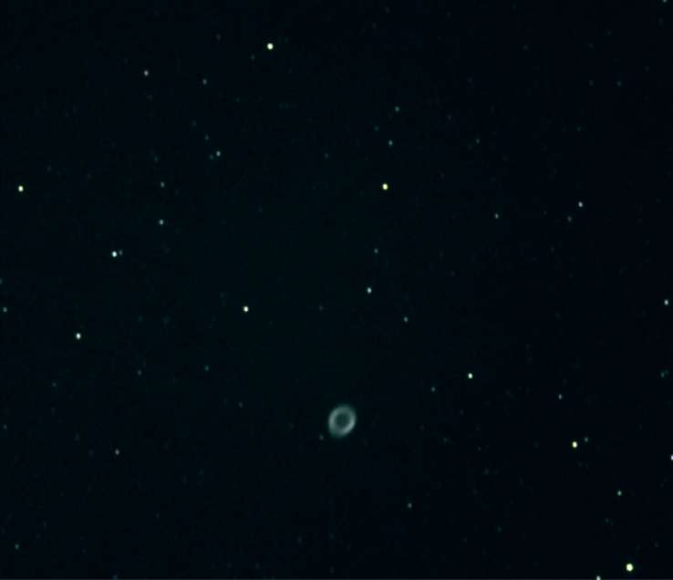

```python
def display_pretty_image(image_path):
    """
    Display the pretty image specified by the given file path.

    :param image_path: The path to the pretty image file to be displayed.
    :type image_path: str
    """
    # Display the pretty image
    display(Image(image_path))

# Call the function with the specified image path
display_pretty_image(r"C:\Users\sunyx\OneDrive\Documents\GitHub\AST_443\Lab_1\FITS_Files\pretty_picture.png")
```

The `display_pretty_image` function is designed to show an image of the astronomical object, in this case, the Ring Nebula. It takes a single parameter, `image_path`, which specifies the location of the image file to be displayed. Inside the function, the `display` method from the IPython library is used alongside the `Image` class to render the image in a notebook or similar environment. When called with the appropriate file path, the function efficiently displays the Ring Nebula image.

Some important lessons I learned from this lab include, ensure that flat fields are captured for each photometric band (red, blue, and visible) during the same observational session to maintain consistency and accuracy in calibration. This helps account for variations in sensitivity and vignetting effects across different bands. Moreover, we cannot neglect the environmental factors, such as temperature and humidity, during data acquisition. This will help in identifying potential influences on the CCD's performance and assist in developing a more comprehensive calibration strategy.